# Risk Factor Analysis

## Outcome Variable

**Outcome Variable:** sstunted

## Predictor Variables

**Intervention Variable:** enwast

**Adjustment Set:**

- arm
- sex
- W_mage
- meducyrs
- feducyrs
- vagbrth
- single
- brthmon
- W_parity
- delta_W_mage
- delta_meducyrs
- delta_feducyrs
- delta_vagbrth
- delta_single
- delta_brthmon
- delta_W_parity

## Stratifying Variables

The analysis was stratified on these variable(s):

- agecat
- studyid
- country

## Data Summary

| agecat | studyid | country | enwast | sstunted | n_cell | n |
| --- | --- | --- | --- | --- | --- | --- |
| Birth | ki0047075b-MAL-ED | BANGLADESH | 0 | 0 | 200 | 241 |
| Birth | ki0047075b-MAL-ED | BANGLADESH | 0 | 1 | 1 | 241 |
| Birth | ki0047075b-MAL-ED | BANGLADESH | 1 | 0 | 40 | 241 |
| Birth | ki0047075b-MAL-ED | BANGLADESH | 1 | 1 | 0 | 241 |
| Birth | ki0047075b-MAL-ED | BRAZIL | 0 | 0 | 175 | 183 |
| Birth | ki0047075b-MAL-ED | BRAZIL | 0 | 1 | 2 | 183 |
| Birth | ki0047075b-MAL-ED | BRAZIL | 1 | 0 | 6 | 183 |
| Birth | ki0047075b-MAL-ED | BRAZIL | 1 | 1 | 0 | 183 |
| Birth | ki0047075b-MAL-ED | INDIA | 0 | 0 | 167 | 203 |
| Birth | ki0047075b-MAL-ED | INDIA | 0 | 1 | 3 | 203 |
| Birth | ki0047075b-MAL-ED | INDIA | 1 | 0 | 32 | 203 |
| Birth | ki0047075b-MAL-ED | INDIA | 1 | 1 | 1 | 203 |
| Birth | ki0047075b-MAL-ED | NEPAL | 0 | 0 | 146 | 169 |
| Birth | ki0047075b-MAL-ED | NEPAL | 0 | 1 | 2 | 169 |
| Birth | ki0047075b-MAL-ED | NEPAL | 1 | 0 | 21 | 169 |
| Birth | ki0047075b-MAL-ED | NEPAL | 1 | 1 | 0 | 169 |
| Birth | ki0047075b-MAL-ED | PERU | 0 | 0 | 271 | 279 |
| Birth | ki0047075b-MAL-ED | PERU | 0 | 1 | 2 | 279 |
| Birth | ki0047075b-MAL-ED | PERU | 1 | 0 | 6 | 279 |
| Birth | ki0047075b-MAL-ED | PERU | 1 | 1 | 0 | 279 |
| Birth | ki0047075b-MAL-ED | SOUTH AFRICA | 0 | 0 | 240 | 260 |
| Birth | ki0047075b-MAL-ED | SOUTH AFRICA | 0 | 1 | 0 | 260 |
| Birth | ki0047075b-MAL-ED | SOUTH AFRICA | 1 | 0 | 20 | 260 |
| Birth | ki0047075b-MAL-ED | SOUTH AFRICA | 1 | 1 | 0 | 260 |
| Birth | ki0047075b-MAL-ED | TANZANIA, UNITED REPUBLIC OF | 0 | 0 | 115 | 118 |
| Birth | ki0047075b-MAL-ED | TANZANIA, UNITED REPUBLIC OF | 0 | 1 | 1 | 118 |
| Birth | ki0047075b-MAL-ED | TANZANIA, UNITED REPUBLIC OF | 1 | 0 | 2 | 118 |
| Birth | ki0047075b-MAL-ED | TANZANIA, UNITED REPUBLIC OF | 1 | 1 | 0 | 118 |
| Birth | ki1000108-CMC-V-BCS-2002 | INDIA | 0 | 0 | 74 | 85 |
| Birth | ki1000108-CMC-V-BCS-2002 | INDIA | 0 | 1 | 0 | 85 |

[output cut: 314 more lines]

The following strata were considered:

- agecat: 24 months, studyid: ki0047075b-MAL-ED, country: BANGLADESH
- agecat: 24 months, studyid: ki0047075b-MAL-ED, country: BRAZIL
- agecat: 24 months, studyid: ki0047075b-MAL-ED, country: INDIA
- agecat: 24 months, studyid: ki0047075b-MAL-ED, country: NEPAL
- agecat: 24 months, studyid: ki0047075b-MAL-ED, country: PERU
- agecat: 24 months, studyid: ki0047075b-MAL-ED, country: SOUTH AFRICA
- agecat: 24 months, studyid: ki0047075b-MAL-ED, country: TANZANIA, UNITED REPUBLIC OF
- agecat: 24 months, studyid: ki1000108-CMC-V-BCS-2002, country: INDIA
- agecat: 24 months, studyid: ki1000108-IRC, country: INDIA
- agecat: 24 months, studyid: ki1017093-NIH-Birth, country: BANGLADESH
- agecat: 24 months, studyid: ki1017093b-PROVIDE, country: BANGLADESH
- agecat: 24 months, studyid: ki1017093c-NIH-Crypto, country: BANGLADESH
- agecat: 24 months, studyid: ki1066203-TanzaniaChild2, country: TANZANIA, UNITED REPUBLIC OF
- agecat: 24 months, studyid: ki1101329-Keneba, country: GAMBIA
- agecat: 24 months, studyid: ki1113344-GMS-Nepal, country: NEPAL
- agecat: 24 months, studyid: ki1114097-CMIN, country: BANGLADESH
- agecat: 24 months, studyid: ki1114097-CMIN, country: GUINEA-BISSAU
- agecat: 24 months, studyid: ki1114097-CMIN, country: PERU
- agecat: 24 months, studyid: ki1114097-CONTENT, country: PERU
- agecat: 24 months, studyid: ki1119695-PROBIT, country: BELARUS
- agecat: 24 months, studyid: ki1126311-ZVITAMBO, country: ZIMBABWE
- agecat: 24 months, studyid: ki1135781-COHORTS, country: GUATEMALA
- agecat: 24 months, studyid: ki1135781-COHORTS, country: INDIA
- agecat: 24 months, studyid: ki1135781-COHORTS, country: PHILIPPINES
- agecat: 24 months, studyid: ki1148112-LCNI-5, country: MALAWI
- agecat: 24 months, studyid: kiGH5241-JiVitA-3, country: BANGLADESH
- agecat: 24 months, studyid: kiGH5241-JiVitA-4, country: BANGLADESH
- agecat: 6 months, studyid: ki0047075b-MAL-ED, country: BANGLADESH
- agecat: 6 months, studyid: ki0047075b-MAL-ED, country: BRAZIL
- agecat: 6 months, studyid: ki0047075b-MAL-ED, country: INDIA
- agecat: 6 months, studyid: ki0047075b-MAL-ED, country: NEPAL
- agecat: 6 months, studyid: ki0047075b-MAL-ED, country: PERU
- agecat: 6 months, studyid: ki0047075b-MAL-ED, country: SOUTH AFRICA
- agecat: 6 months, studyid: ki0047075b-MAL-ED, country: TANZANIA, UNITED REPUBLIC OF
- agecat: 6 months, studyid: ki1000108-CMC-V-BCS-2002, country: INDIA
- agecat: 6 months, studyid: ki1000108-IRC, country: INDIA
- agecat: 6 months, studyid: ki1000109-EE, country: PAKISTAN
- agecat: 6 months, studyid: ki1000109-ResPak, country: PAKISTAN
- agecat: 6 months, studyid: ki1000304b-SAS-CompFeed, country: INDIA
- agecat: 6 months, studyid: ki1000304b-SAS-FoodSuppl, country: INDIA
- agecat: 6 months, studyid: ki1017093-NIH-Birth, country: BANGLADESH
- agecat: 6 months, studyid: ki1017093b-PROVIDE, country: BANGLADESH
- agecat: 6 months, studyid: ki1017093c-NIH-Crypto, country: BANGLADESH
- agecat: 6 months, studyid: ki1066203-TanzaniaChild2, country: TANZANIA, UNITED REPUBLIC OF
- agecat: 6 months, studyid: ki1101329-Keneba, country: GAMBIA
- agecat: 6 months, studyid: ki1112895-Guatemala BSC, country: GUATEMALA
- agecat: 6 months, studyid: ki1113344-GMS-Nepal, country: NEPAL
- agecat: 6 months, studyid: ki1114097-CMIN, country: BANGLADESH
- agecat: 6 months, studyid: ki1114097-CMIN, country: BRAZIL
- agecat: 6 months, studyid: ki1114097-CMIN, country: GUINEA-BISSAU
- agecat: 6 months, studyid: ki1114097-CMIN, country: PERU
- agecat: 6 months, studyid: ki1114097-CONTENT, country: PERU
- agecat: 6 months, studyid: ki1119695-PROBIT, country: BELARUS
- agecat: 6 months, studyid: ki1126311-ZVITAMBO, country: ZIMBABWE
- agecat: 6 months, studyid: ki1135781-COHORTS, country: GUATEMALA
- agecat: 6 months, studyid: ki1135781-COHORTS, country: INDIA
- agecat: 6 months, studyid: ki1135781-COHORTS, country: PHILIPPINES
- agecat: 6 months, studyid: ki1148112-LCNI-5, country: MALAWI
- agecat: 6 months, studyid: kiGH5241-JiVitA-3, country: BANGLADESH
- agecat: 6 months, studyid: kiGH5241-JiVitA-4, country: BANGLADESH
- agecat: Birth, studyid: ki0047075b-MAL-ED, country: BANGLADESH
- agecat: Birth, studyid: ki0047075b-MAL-ED, country: BRAZIL
- agecat: Birth, studyid: ki0047075b-MAL-ED, country: INDIA
- agecat: Birth, studyid: ki0047075b-MAL-ED, country: NEPAL
- agecat: Birth, studyid: ki0047075b-MAL-ED, country: PERU
- agecat: Birth, studyid: ki0047075b-MAL-ED, country: SOUTH AFRICA
- agecat: Birth, studyid: ki0047075b-MAL-ED, country: TANZANIA, UNITED REPUBLIC OF
- agecat: Birth, studyid: ki1000108-CMC-V-BCS-2002, country: INDIA
- agecat: Birth, studyid: ki1000108-IRC, country: INDIA
- agecat: Birth, studyid: ki1000109-EE, country: PAKISTAN
- agecat: Birth, studyid: ki1000109-ResPak, country: PAKISTAN
- agecat: Birth, studyid: ki1000304b-SAS-CompFeed, country: INDIA
- agecat: Birth, studyid: ki1017093-NIH-Birth, country: BANGLADESH
- agecat: Birth, studyid: ki1017093c-NIH-Crypto, country: BANGLADESH
- agecat: Birth, studyid: ki1101329-Keneba, country: GAMBIA
- agecat: Birth, studyid: ki1114097-CMIN, country: BANGLADESH
- agecat: Birth, studyid: ki1114097-CMIN, country: BRAZIL
- agecat: Birth, studyid: ki1114097-CMIN, country: PERU
- agecat: Birth, studyid: ki1114097-CONTENT, country: PERU
- agecat: Birth, studyid: ki1119695-PROBIT, country: BELARUS
- agecat: Birth, studyid: ki1126311-ZVITAMBO, country: ZIMBABWE
- agecat: Birth, studyid: ki1135781-COHORTS, country: GUATEMALA
- agecat: Birth, studyid: ki1135781-COHORTS, country: INDIA
- agecat: Birth, studyid: ki1135781-COHORTS, country: PHILIPPINES
- agecat: Birth, studyid: kiGH5241-JiVitA-3, country: BANGLADESH
- agecat: Birth, studyid: kiGH5241-JiVitA-4, country: BANGLADESH

### Dropped Strata

Some strata were dropped due to rare outcomes:

- agecat: Birth, studyid: ki0047075b-MAL-ED, country: BANGLADESH
- agecat: Birth, studyid: ki0047075b-MAL-ED, country: BRAZIL
- agecat: Birth, studyid: ki0047075b-MAL-ED, country: INDIA
- agecat: Birth, studyid: ki0047075b-MAL-ED, country: NEPAL
- agecat: Birth, studyid: ki0047075b-MAL-ED, country: PERU
- agecat: Birth, studyid: ki0047075b-MAL-ED, country: SOUTH AFRICA
- agecat: Birth, studyid: ki0047075b-MAL-ED, country: TANZANIA, UNITED REPUBLIC OF
- agecat: Birth, studyid: ki1000108-CMC-V-BCS-2002, country: INDIA
- agecat: Birth, studyid: ki1000108-IRC, country: INDIA
- agecat: Birth, studyid: ki1000109-EE, country: PAKISTAN
- agecat: Birth, studyid: ki1000109-ResPak, country: PAKISTAN
- agecat: Birth, studyid: ki1000304b-SAS-CompFeed, country: INDIA
- agecat: Birth, studyid: ki1017093-NIH-Birth, country: BANGLADESH
- agecat: Birth, studyid: ki1017093c-NIH-Crypto, country: BANGLADESH
- agecat: Birth, studyid: ki1101329-Keneba, country: GAMBIA
- agecat: Birth, studyid: ki1114097-CMIN, country: BANGLADESH
- agecat: Birth, studyid: ki1114097-CMIN, country: BRAZIL
- agecat: Birth, studyid: ki1114097-CMIN, country: PERU
- agecat: Birth, studyid: ki1114097-CONTENT, country: PERU
- agecat: Birth, studyid: ki1119695-PROBIT, country: BELARUS
- agecat: Birth, studyid: ki1126311-ZVITAMBO, country: ZIMBABWE
- agecat: Birth, studyid: ki1135781-COHORTS, country: GUATEMALA
- agecat: Birth, studyid: ki1135781-COHORTS, country: INDIA
- agecat: Birth, studyid: ki1135781-COHORTS, country: PHILIPPINES
- agecat: Birth, studyid: kiGH5241-JiVitA-3, country: BANGLADESH
- agecat: Birth, studyid: kiGH5241-JiVitA-4, country: BANGLADESH
- agecat: 6 months, studyid: ki0047075b-MAL-ED, country: BANGLADESH
- agecat: 6 months, studyid: ki0047075b-MAL-ED, country: BRAZIL
- agecat: 6 months, studyid: ki0047075b-MAL-ED, country: INDIA
- agecat: 6 months, studyid: ki0047075b-MAL-ED, country: NEPAL
- agecat: 6 months, studyid: ki0047075b-MAL-ED, country: PERU
- agecat: 6 months, studyid: ki0047075b-MAL-ED, country: SOUTH AFRICA
- agecat: 6 months, studyid: ki0047075b-MAL-ED, country: TANZANIA, UNITED REPUBLIC OF
- agecat: 6 months, studyid: ki1066203-TanzaniaChild2, country: TANZANIA, UNITED REPUBLIC OF
- agecat: 6 months, studyid: ki1112895-Guatemala BSC, country: GUATEMALA
- agecat: 6 months, studyid: ki1114097-CMIN, country: BANGLADESH
- agecat: 6 months, studyid: ki1114097-CMIN, country: BRAZIL
- agecat: 6 months, studyid: ki1114097-CMIN, country: GUINEA-BISSAU
- agecat: 6 months, studyid: ki1114097-CMIN, country: PERU
- agecat: 6 months, studyid: ki1114097-CONTENT, country: PERU
- agecat: 24 months, studyid: ki0047075b-MAL-ED, country: BRAZIL
- agecat: 24 months, studyid: ki0047075b-MAL-ED, country: NEPAL
- agecat: 24 months, studyid: ki0047075b-MAL-ED, country: PERU
- agecat: 24 months, studyid: ki0047075b-MAL-ED, country: SOUTH AFRICA
- agecat: 24 months, studyid: ki0047075b-MAL-ED, country: TANZANIA, UNITED REPUBLIC OF
- agecat: 24 months, studyid: ki1066203-TanzaniaChild2, country: TANZANIA, UNITED REPUBLIC OF
- agecat: 24 months, studyid: ki1114097-CMIN, country: PERU
- agecat: 24 months, studyid: ki1114097-CONTENT, country: PERU
- agecat: 24 months, studyid: ki1148112-LCNI-5, country: MALAWI

## Methods Detail

We’re interested in the causal parameters $E[Y_a]$ for all values of $a \in \mathcal{A}$. These parameters represent the mean outcome if, possibly contrary to fact, we intervened to set all units to have $A=a$. Under the randomization and positivity assumptions, these are identified by the statistical parameters $\psi_a=E_W[E_{Y|A,W}(Y|A=a,W)]$. In addition, we’re interested in the mean of $Y$, $E[Y]$ under no intervention (the observed mean). We will estimate these parameters by using SuperLearner to fit the relevant likelihood factors – $E_{Y|A,W}(Y|A=a,W)$ and $p(A=a|W)$, and then updating our likelihood fit using a joint TMLE.

For unadjusted analyses ($W=\{\}$), initial likelihoods were estimated using Lrnr_glm to estimate the simple $E(Y|A)$ and Lrnr_mean to estimate $p(A)$. For adjusted analyses, a small library containing Lrnr_glmnet, Lrnr_xgboost, and Lrnr_mean was used.

Having estimated these parameters, we will then use the delta method to estimate relative risks and attributable risks relative to a prespecified baseline level of $A$.

# Results Detail

## Results Plots

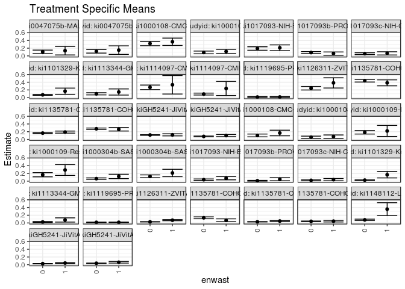

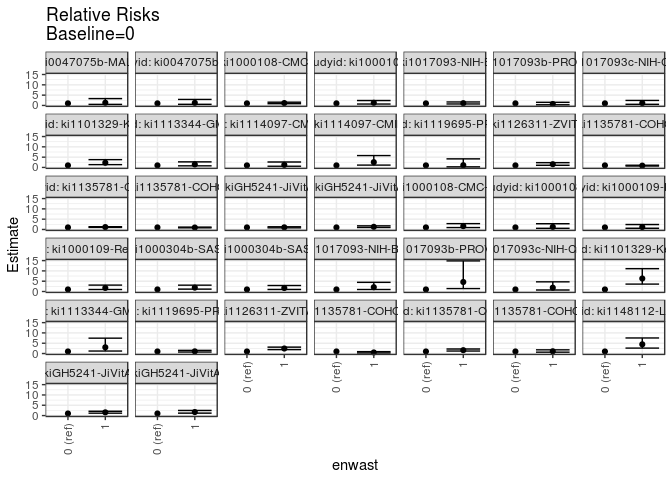

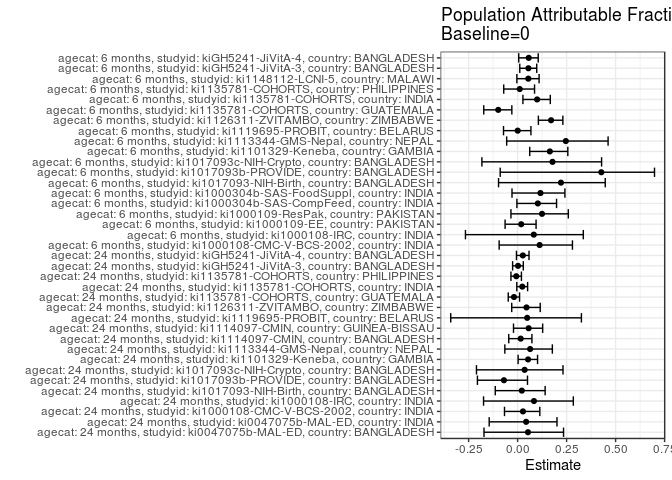

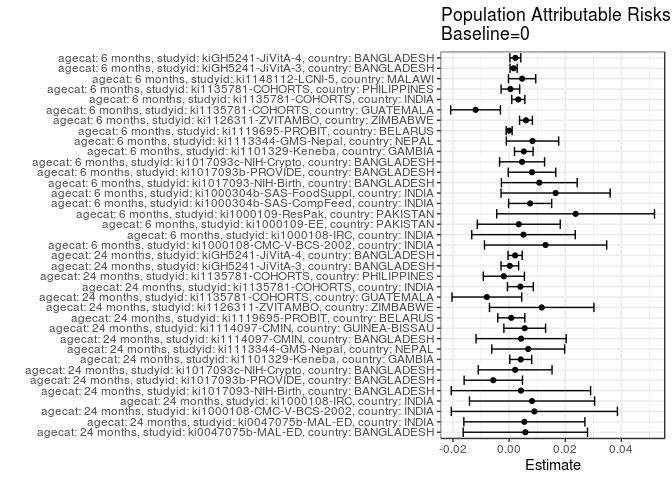

## Results Table

### Parameter: TSM

| agecat | studyid | country | intervention_level | baseline_level | estimate | ci_lower | ci_upper |
| --- | --- | --- | --- | --- | --- | --- | --- |
| 6 months | ki1000108-CMC-V-BCS-2002 | INDIA | 0 | NA | 0.1027073 | 0.0662993 | 0.1391154 |
| 6 months | ki1000108-CMC-V-BCS-2002 | INDIA | 1 | NA | 0.1665549 | 0.0940035 | 0.2391064 |
| 6 months | ki1000108-IRC | INDIA | 0 | NA | 0.0568930 | 0.0282796 | 0.0855064 |
| 6 months | ki1000108-IRC | INDIA | 1 | NA | 0.0712774 | 0.0266493 | 0.1159055 |
| 6 months | ki1000109-EE | PAKISTAN | 0 | NA | 0.1836735 | 0.1393436 | 0.2280034 |
| 6 months | ki1000109-EE | PAKISTAN | 1 | NA | 0.2187500 | 0.0752971 | 0.3622029 |
| 6 months | ki1000109-ResPak | PAKISTAN | 0 | NA | 0.1665680 | 0.1125433 | 0.2205927 |
| 6 months | ki1000109-ResPak | PAKISTAN | 1 | NA | 0.2898085 | 0.1492384 | 0.4303786 |
| 6 months | ki1000304b-SAS-CompFeed | INDIA | 0 | NA | 0.0650528 | 0.0461089 | 0.0839968 |
| 6 months | ki1000304b-SAS-CompFeed | INDIA | 1 | NA | 0.1225237 | 0.0661569 | 0.1788905 |
| 6 months | ki1000304b-SAS-FoodSuppl | INDIA | 0 | NA | 0.1255366 | 0.0886754 | 0.1623978 |
| 6 months | ki1000304b-SAS-FoodSuppl | INDIA | 1 | NA | 0.2126043 | 0.1167985 | 0.3084101 |
| 6 months | ki1017093-NIH-Birth | BANGLADESH | 0 | NA | 0.0378785 | 0.0181219 | 0.0576351 |
| 6 months | ki1017093-NIH-Birth | BANGLADESH | 1 | NA | 0.0788338 | 0.0350938 | 0.1225738 |
| 6 months | ki1017093b-PROVIDE | BANGLADESH | 0 | NA | 0.0109409 | 0.0013953 | 0.0204866 |
| 6 months | ki1017093b-PROVIDE | BANGLADESH | 1 | NA | 0.0504202 | 0.0110724 | 0.0897679 |
| 6 months | ki1017093c-NIH-Crypto | BANGLADESH | 0 | NA | 0.0213178 | 0.0088460 | 0.0337896 |
| 6 months | ki1017093c-NIH-Crypto | BANGLADESH | 1 | NA | 0.0393258 | 0.0107514 | 0.0679003 |
| 6 months | ki1101329-Keneba | GAMBIA | 0 | NA | 0.0265309 | 0.0194914 | 0.0335705 |
| 6 months | ki1101329-Keneba | GAMBIA | 1 | NA | 0.1672283 | 0.0839309 | 0.2505257 |
| 6 months | ki1113344-GMS-Nepal | NEPAL | 0 | NA | 0.0255319 | 0.0112590 | 0.0398048 |
| 6 months | ki1113344-GMS-Nepal | NEPAL | 1 | NA | 0.0769231 | 0.0221254 | 0.1317207 |
| 6 months | ki1119695-PROBIT | BELARUS | 0 | NA | 0.0152897 | 0.0096178 | 0.0209617 |
| 6 months | ki1119695-PROBIT | BELARUS | 1 | NA | 0.0161265 | 0.0099129 | 0.0223401 |
| 6 months | ki1126311-ZVITAMBO | ZIMBABWE | 0 | NA | 0.0291712 | 0.0251097 | 0.0332327 |
| 6 months | ki1126311-ZVITAMBO | ZIMBABWE | 1 | NA | 0.0709729 | 0.0567242 | 0.0852217 |
| 6 months | ki1135781-COHORTS | GUATEMALA | 0 | NA | 0.1329243 | 0.1082084 | 0.1576401 |
| 6 months | ki1135781-COHORTS | GUATEMALA | 1 | NA | 0.0687662 | 0.0318175 | 0.1057148 |
| 6 months | ki1135781-COHORTS | INDIA | 0 | NA | 0.0296055 | 0.0250605 | 0.0341506 |
| 6 months | ki1135781-COHORTS | INDIA | 1 | NA | 0.0480509 | 0.0355593 | 0.0605426 |
| 6 months | ki1135781-COHORTS | PHILIPPINES | 0 | NA | 0.0415768 | 0.0332227 | 0.0499310 |
| 6 months | ki1135781-COHORTS | PHILIPPINES | 1 | NA | 0.0456083 | 0.0251067 | 0.0661099 |
| 6 months | ki1148112-LCNI-5 | MALAWI | 0 | NA | 0.0800000 | 0.0613187 | 0.0986813 |
| 6 months | ki1148112-LCNI-5 | MALAWI | 1 | NA | 0.3571429 | 0.1895146 | 0.5247712 |
| 6 months | kiGH5241-JiVitA-3 | BANGLADESH | 0 | NA | 0.0274729 | 0.0244005 | 0.0305453 |
| 6 months | kiGH5241-JiVitA-3 | BANGLADESH | 1 | NA | 0.0427222 | 0.0312974 | 0.0541470 |
| 6 months | kiGH5241-JiVitA-4 | BANGLADESH | 0 | NA | 0.0370017 | 0.0310243 | 0.0429791 |
| 6 months | kiGH5241-JiVitA-4 | BANGLADESH | 1 | NA | 0.0629432 | 0.0417710 | 0.0841154 |
| 24 months | ki0047075b-MAL-ED | BANGLADESH | 0 | NA | 0.1036585 | 0.0568906 | 0.1504265 |
| 24 months | ki0047075b-MAL-ED | BANGLADESH | 1 | NA | 0.1351351 | 0.0247048 | 0.2455655 |
| 24 months | ki0047075b-MAL-ED | INDIA | 0 | NA | 0.1195652 | 0.0725799 | 0.1665505 |
| 24 months | ki0047075b-MAL-ED | INDIA | 1 | NA | 0.1500000 | 0.0390966 | 0.2609034 |
| 24 months | ki1000108-CMC-V-BCS-2002 | INDIA | 0 | NA | 0.3197686 | 0.2638642 | 0.3756729 |
| 24 months | ki1000108-CMC-V-BCS-2002 | INDIA | 1 | NA | 0.3657914 | 0.2704888 | 0.4610939 |
| 24 months | ki1000108-IRC | INDIA | 0 | NA | 0.0897633 | 0.0543246 | 0.1252020 |
| 24 months | ki1000108-IRC | INDIA | 1 | NA | 0.1143632 | 0.0593053 | 0.1694212 |
| 24 months | ki1017093-NIH-Birth | BANGLADESH | 0 | NA | 0.1913904 | 0.1460789 | 0.2367019 |
| 24 months | ki1017093-NIH-Birth | BANGLADESH | 1 | NA | 0.2092751 | 0.1337510 | 0.2847992 |
| 24 months | ki1017093b-PROVIDE | BANGLADESH | 0 | NA | 0.0864745 | 0.0605120 | 0.1124370 |
| 24 months | ki1017093b-PROVIDE | BANGLADESH | 1 | NA | 0.0593220 | 0.0166624 | 0.1019817 |
| 24 months | ki1017093c-NIH-Crypto | BANGLADESH | 0 | NA | 0.0578512 | 0.0338106 | 0.0818919 |
| 24 months | ki1017093c-NIH-Crypto | BANGLADESH | 1 | NA | 0.0656934 | 0.0241667 | 0.1072202 |
| 24 months | ki1101329-Keneba | GAMBIA | 0 | NA | 0.0733609 | 0.0607228 | 0.0859989 |
| 24 months | ki1101329-Keneba | GAMBIA | 1 | NA | 0.1673889 | 0.0870332 | 0.2477445 |
| 24 months | ki1113344-GMS-Nepal | NEPAL | 0 | NA | 0.0998265 | 0.0711634 | 0.1284896 |
| 24 months | ki1113344-GMS-Nepal | NEPAL | 1 | NA | 0.1464768 | 0.0670566 | 0.2258969 |
| 24 months | ki1114097-CMIN | BANGLADESH | 0 | NA | 0.2672811 | 0.2082734 | 0.3262889 |
| 24 months | ki1114097-CMIN | BANGLADESH | 1 | NA | 0.3333333 | 0.0942583 | 0.5724084 |
| 24 months | ki1114097-CMIN | GUINEA-BISSAU | 0 | NA | 0.0929791 | 0.0681626 | 0.1177956 |
| 24 months | ki1114097-CMIN | GUINEA-BISSAU | 1 | NA | 0.2380952 | 0.0557641 | 0.4204263 |
| 24 months | ki1119695-PROBIT | BELARUS | 0 | NA | 0.0150965 | 0.0001917 | 0.0300014 |
| 24 months | ki1119695-PROBIT | BELARUS | 1 | NA | 0.0164747 | 0.0031057 | 0.0298437 |
| 24 months | ki1126311-ZVITAMBO | ZIMBABWE | 0 | NA | 0.2440237 | 0.1985717 | 0.2894758 |
| 24 months | ki1126311-ZVITAMBO | ZIMBABWE | 1 | NA | 0.3825614 | 0.2504284 | 0.5146944 |
| 24 months | ki1135781-COHORTS | GUATEMALA | 0 | NA | 0.4374693 | 0.4046333 | 0.4703053 |
| 24 months | ki1135781-COHORTS | GUATEMALA | 1 | NA | 0.3837435 | 0.3066790 | 0.4608079 |
| 24 months | ki1135781-COHORTS | INDIA | 0 | NA | 0.1634172 | 0.1523067 | 0.1745277 |
| 24 months | ki1135781-COHORTS | INDIA | 1 | NA | 0.1898675 | 0.1631113 | 0.2166237 |
| 24 months | ki1135781-COHORTS | PHILIPPINES | 0 | NA | 0.2754206 | 0.2557809 | 0.2950604 |
| 24 months | ki1135781-COHORTS | PHILIPPINES | 1 | NA | 0.2625975 | 0.2177685 | 0.3074264 |
| 24 months | kiGH5241-JiVitA-3 | BANGLADESH | 0 | NA | 0.1147134 | 0.1057491 | 0.1236777 |
| 24 months | kiGH5241-JiVitA-3 | BANGLADESH | 1 | NA | 0.1181566 | 0.0912617 | 0.1450515 |
| 24 months | kiGH5241-JiVitA-4 | BANGLADESH | 0 | NA | 0.0775848 | 0.0678409 | 0.0873287 |
| 24 months | kiGH5241-JiVitA-4 | BANGLADESH | 1 | NA | 0.0999940 | 0.0717707 | 0.1282172 |

### Parameter: E(Y)

| agecat | studyid | country | intervention_level | baseline_level | estimate | ci_lower | ci_upper |
| --- | --- | --- | --- | --- | --- | --- | --- |
| 6 months | ki1000108-CMC-V-BCS-2002 | INDIA | NA | NA | 0.1157025 | 0.0827518 | 0.1486532 |
| 6 months | ki1000108-IRC | INDIA | NA | NA | 0.0620155 | 0.0379551 | 0.0860759 |
| 6 months | ki1000109-EE | PAKISTAN | NA | NA | 0.1871166 | 0.1447155 | 0.2295176 |
| 6 months | ki1000109-ResPak | PAKISTAN | NA | NA | 0.1902655 | 0.1389784 | 0.2415526 |
| 6 months | ki1000304b-SAS-CompFeed | INDIA | NA | NA | 0.0725474 | 0.0527677 | 0.0923271 |
| 6 months | ki1000304b-SAS-FoodSuppl | INDIA | NA | NA | 0.1421053 | 0.1069532 | 0.1772573 |
| 6 months | ki1017093-NIH-Birth | BANGLADESH | NA | NA | 0.0486381 | 0.0300237 | 0.0672526 |
| 6 months | ki1017093b-PROVIDE | BANGLADESH | NA | NA | 0.0190972 | 0.0079103 | 0.0302842 |
| 6 months | ki1017093c-NIH-Crypto | BANGLADESH | NA | NA | 0.0259366 | 0.0141026 | 0.0377706 |
| 6 months | ki1101329-Keneba | GAMBIA | NA | NA | 0.0317613 | 0.0242196 | 0.0393030 |
| 6 months | ki1113344-GMS-Nepal | NEPAL | NA | NA | 0.0338681 | 0.0188862 | 0.0488500 |
| 6 months | ki1119695-PROBIT | BELARUS | NA | NA | 0.0152977 | 0.0100190 | 0.0205764 |
| 6 months | ki1126311-ZVITAMBO | ZIMBABWE | NA | NA | 0.0351816 | 0.0311045 | 0.0392588 |
| 6 months | ki1135781-COHORTS | GUATEMALA | NA | NA | 0.1209767 | 0.0996719 | 0.1422815 |
| 6 months | ki1135781-COHORTS | INDIA | NA | NA | 0.0328826 | 0.0285497 | 0.0372155 |
| 6 months | ki1135781-COHORTS | PHILIPPINES | NA | NA | 0.0420363 | 0.0343109 | 0.0497616 |
| 6 months | ki1148112-LCNI-5 | MALAWI | NA | NA | 0.0846246 | 0.0657805 | 0.1034686 |
| 6 months | kiGH5241-JiVitA-3 | BANGLADESH | NA | NA | 0.0290812 | 0.0261221 | 0.0320403 |
| 6 months | kiGH5241-JiVitA-4 | BANGLADESH | NA | NA | 0.0392290 | 0.0334844 | 0.0449737 |
| 24 months | ki0047075b-MAL-ED | BANGLADESH | NA | NA | 0.1094527 | 0.0661839 | 0.1527215 |
| 24 months | ki0047075b-MAL-ED | INDIA | NA | NA | 0.1250000 | 0.0815935 | 0.1684065 |
| 24 months | ki1000108-CMC-V-BCS-2002 | INDIA | NA | NA | 0.3287671 | 0.2805081 | 0.3770261 |
| 24 months | ki1000108-IRC | INDIA | NA | NA | 0.0979381 | 0.0683249 | 0.1275514 |
| 24 months | ki1017093-NIH-Birth | BANGLADESH | NA | NA | 0.1955990 | 0.1571099 | 0.2340881 |
| 24 months | ki1017093b-PROVIDE | BANGLADESH | NA | NA | 0.0808436 | 0.0584259 | 0.1032613 |
| 24 months | ki1017093c-NIH-Crypto | BANGLADESH | NA | NA | 0.0600000 | 0.0391629 | 0.0808371 |
| 24 months | ki1101329-Keneba | GAMBIA | NA | NA | 0.0775058 | 0.0648507 | 0.0901609 |
| 24 months | ki1113344-GMS-Nepal | NEPAL | NA | NA | 0.1066398 | 0.0794767 | 0.1338030 |
| 24 months | ki1114097-CMIN | BANGLADESH | NA | NA | 0.2715517 | 0.2141972 | 0.3289063 |
| 24 months | ki1114097-CMIN | GUINEA-BISSAU | NA | NA | 0.0985401 | 0.0735635 | 0.1235168 |
| 24 months | ki1119695-PROBIT | BELARUS | NA | NA | 0.0158730 | 0.0044440 | 0.0273021 |
| 24 months | ki1126311-ZVITAMBO | ZIMBABWE | NA | NA | 0.2556391 | 0.2127831 | 0.2984951 |
| 24 months | ki1135781-COHORTS | GUATEMALA | NA | NA | 0.4295432 | 0.3992834 | 0.4598031 |
| 24 months | ki1135781-COHORTS | INDIA | NA | NA | 0.1674226 | 0.1571457 | 0.1776995 |
| 24 months | ki1135781-COHORTS | PHILIPPINES | NA | NA | 0.2735407 | 0.2555022 | 0.2915792 |
| 24 months | kiGH5241-JiVitA-3 | BANGLADESH | NA | NA | 0.1149648 | 0.1064894 | 0.1234401 |
| 24 months | kiGH5241-JiVitA-4 | BANGLADESH | NA | NA | 0.0797219 | 0.0704575 | 0.0889863 |

### Parameter: RR

| agecat | studyid | country | intervention_level | baseline_level | estimate | ci_lower | ci_upper |
| --- | --- | --- | --- | --- | --- | --- | --- |
| 6 months | ki1000108-CMC-V-BCS-2002 | INDIA | 0 | 0 | 1.0000000 | 1.0000000 | 1.0000000 |
| 6 months | ki1000108-CMC-V-BCS-2002 | INDIA | 1 | 0 | 1.6216456 | 0.9243142 | 2.8450657 |
| 6 months | ki1000108-IRC | INDIA | 0 | 0 | 1.0000000 | 1.0000000 | 1.0000000 |
| 6 months | ki1000108-IRC | INDIA | 1 | 0 | 1.2528320 | 0.5619470 | 2.7931246 |
| 6 months | ki1000109-EE | PAKISTAN | 0 | 0 | 1.0000000 | 1.0000000 | 1.0000000 |
| 6 months | ki1000109-EE | PAKISTAN | 1 | 0 | 1.1909722 | 0.5921368 | 2.3954175 |
| 6 months | ki1000109-ResPak | PAKISTAN | 0 | 0 | 1.0000000 | 1.0000000 | 1.0000000 |
| 6 months | ki1000109-ResPak | PAKISTAN | 1 | 0 | 1.7398810 | 0.9713925 | 3.1163367 |
| 6 months | ki1000304b-SAS-CompFeed | INDIA | 0 | 0 | 1.0000000 | 1.0000000 | 1.0000000 |
| 6 months | ki1000304b-SAS-CompFeed | INDIA | 1 | 0 | 1.8834489 | 1.1516977 | 3.0801310 |
| 6 months | ki1000304b-SAS-FoodSuppl | INDIA | 0 | 0 | 1.0000000 | 1.0000000 | 1.0000000 |
| 6 months | ki1000304b-SAS-FoodSuppl | INDIA | 1 | 0 | 1.6935639 | 0.9877396 | 2.9037601 |
| 6 months | ki1017093-NIH-Birth | BANGLADESH | 0 | 0 | 1.0000000 | 1.0000000 | 1.0000000 |
| 6 months | ki1017093-NIH-Birth | BANGLADESH | 1 | 0 | 2.0812274 | 0.9724792 | 4.4540876 |
| 6 months | ki1017093b-PROVIDE | BANGLADESH | 0 | 0 | 1.0000000 | 1.0000000 | 1.0000000 |
| 6 months | ki1017093b-PROVIDE | BANGLADESH | 1 | 0 | 4.6084034 | 1.4294855 | 14.8566610 |
| 6 months | ki1017093c-NIH-Crypto | BANGLADESH | 0 | 0 | 1.0000000 | 1.0000000 | 1.0000000 |
| 6 months | ki1017093c-NIH-Crypto | BANGLADESH | 1 | 0 | 1.8447395 | 0.7257688 | 4.6889094 |
| 6 months | ki1101329-Keneba | GAMBIA | 0 | 0 | 1.0000000 | 1.0000000 | 1.0000000 |
| 6 months | ki1101329-Keneba | GAMBIA | 1 | 0 | 6.3031406 | 3.5854458 | 11.0807927 |
| 6 months | ki1113344-GMS-Nepal | NEPAL | 0 | 0 | 1.0000000 | 1.0000000 | 1.0000000 |
| 6 months | ki1113344-GMS-Nepal | NEPAL | 1 | 0 | 3.0128205 | 1.2181721 | 7.4513996 |
| 6 months | ki1119695-PROBIT | BELARUS | 0 | 0 | 1.0000000 | 1.0000000 | 1.0000000 |
| 6 months | ki1119695-PROBIT | BELARUS | 1 | 0 | 1.0547272 | 0.7310372 | 1.5217414 |
| 6 months | ki1126311-ZVITAMBO | ZIMBABWE | 0 | 0 | 1.0000000 | 1.0000000 | 1.0000000 |
| 6 months | ki1126311-ZVITAMBO | ZIMBABWE | 1 | 0 | 2.4329803 | 1.9060254 | 3.1056212 |
| 6 months | ki1135781-COHORTS | GUATEMALA | 0 | 0 | 1.0000000 | 1.0000000 | 1.0000000 |
| 6 months | ki1135781-COHORTS | GUATEMALA | 1 | 0 | 0.5173334 | 0.2930964 | 0.9131256 |
| 6 months | ki1135781-COHORTS | INDIA | 0 | 0 | 1.0000000 | 1.0000000 | 1.0000000 |
| 6 months | ki1135781-COHORTS | INDIA | 1 | 0 | 1.6230392 | 1.2002760 | 2.1947087 |
| 6 months | ki1135781-COHORTS | PHILIPPINES | 0 | 0 | 1.0000000 | 1.0000000 | 1.0000000 |
| 6 months | ki1135781-COHORTS | PHILIPPINES | 1 | 0 | 1.0969646 | 0.6705175 | 1.7946308 |
| 6 months | ki1148112-LCNI-5 | MALAWI | 0 | 0 | 1.0000000 | 1.0000000 | 1.0000000 |
| 6 months | ki1148112-LCNI-5 | MALAWI | 1 | 0 | 4.4642857 | 2.6428796 | 7.5409592 |
| 6 months | kiGH5241-JiVitA-3 | BANGLADESH | 0 | 0 | 1.0000000 | 1.0000000 | 1.0000000 |
| 6 months | kiGH5241-JiVitA-3 | BANGLADESH | 1 | 0 | 1.5550674 | 1.1599040 | 2.0848575 |
| 6 months | kiGH5241-JiVitA-4 | BANGLADESH | 0 | 0 | 1.0000000 | 1.0000000 | 1.0000000 |
| 6 months | kiGH5241-JiVitA-4 | BANGLADESH | 1 | 0 | 1.7010891 | 1.1716132 | 2.4698459 |
| 24 months | ki0047075b-MAL-ED | BANGLADESH | 0 | 0 | 1.0000000 | 1.0000000 | 1.0000000 |
| 24 months | ki0047075b-MAL-ED | BANGLADESH | 1 | 0 | 1.3036566 | 0.5125857 | 3.3155829 |
| 24 months | ki0047075b-MAL-ED | INDIA | 0 | 0 | 1.0000000 | 1.0000000 | 1.0000000 |
| 24 months | ki0047075b-MAL-ED | INDIA | 1 | 0 | 1.2545455 | 0.5430650 | 2.8981511 |
| 24 months | ki1000108-CMC-V-BCS-2002 | INDIA | 0 | 0 | 1.0000000 | 1.0000000 | 1.0000000 |
| 24 months | ki1000108-CMC-V-BCS-2002 | INDIA | 1 | 0 | 1.1439255 | 0.8360601 | 1.5651572 |
| 24 months | ki1000108-IRC | INDIA | 0 | 0 | 1.0000000 | 1.0000000 | 1.0000000 |
| 24 months | ki1000108-IRC | INDIA | 1 | 0 | 1.2740536 | 0.6823177 | 2.3789686 |
| 24 months | ki1017093-NIH-Birth | BANGLADESH | 0 | 0 | 1.0000000 | 1.0000000 | 1.0000000 |
| 24 months | ki1017093-NIH-Birth | BANGLADESH | 1 | 0 | 1.0934462 | 0.7093814 | 1.6854468 |
| 24 months | ki1017093b-PROVIDE | BANGLADESH | 0 | 0 | 1.0000000 | 1.0000000 | 1.0000000 |
| 24 months | ki1017093b-PROVIDE | BANGLADESH | 1 | 0 | 0.6860061 | 0.3146966 | 1.4954226 |
| 24 months | ki1017093c-NIH-Crypto | BANGLADESH | 0 | 0 | 1.0000000 | 1.0000000 | 1.0000000 |
| 24 months | ki1017093c-NIH-Crypto | BANGLADESH | 1 | 0 | 1.1355579 | 0.5329294 | 2.4196293 |
| 24 months | ki1101329-Keneba | GAMBIA | 0 | 0 | 1.0000000 | 1.0000000 | 1.0000000 |
| 24 months | ki1101329-Keneba | GAMBIA | 1 | 0 | 2.2817187 | 1.3706522 | 3.7983670 |
| 24 months | ki1113344-GMS-Nepal | NEPAL | 0 | 0 | 1.0000000 | 1.0000000 | 1.0000000 |
| 24 months | ki1113344-GMS-Nepal | NEPAL | 1 | 0 | 1.4673132 | 0.7942613 | 2.7107051 |
| 24 months | ki1114097-CMIN | BANGLADESH | 0 | 0 | 1.0000000 | 1.0000000 | 1.0000000 |
| 24 months | ki1114097-CMIN | BANGLADESH | 1 | 0 | 1.2471264 | 0.5888451 | 2.6413131 |
| 24 months | ki1114097-CMIN | GUINEA-BISSAU | 0 | 0 | 1.0000000 | 1.0000000 | 1.0000000 |
| 24 months | ki1114097-CMIN | GUINEA-BISSAU | 1 | 0 | 2.5607386 | 1.1380602 | 5.7618938 |
| 24 months | ki1119695-PROBIT | BELARUS | 0 | 0 | 1.0000000 | 1.0000000 | 1.0000000 |
| 24 months | ki1119695-PROBIT | BELARUS | 1 | 0 | 1.0912867 | 0.2860770 | 4.1628881 |
| 24 months | ki1126311-ZVITAMBO | ZIMBABWE | 0 | 0 | 1.0000000 | 1.0000000 | 1.0000000 |
| 24 months | ki1126311-ZVITAMBO | ZIMBABWE | 1 | 0 | 1.5677220 | 1.0568797 | 2.3254794 |
| 24 months | ki1135781-COHORTS | GUATEMALA | 0 | 0 | 1.0000000 | 1.0000000 | 1.0000000 |
| 24 months | ki1135781-COHORTS | GUATEMALA | 1 | 0 | 0.8771895 | 0.7083967 | 1.0862014 |
| 24 months | ki1135781-COHORTS | INDIA | 0 | 0 | 1.0000000 | 1.0000000 | 1.0000000 |
| 24 months | ki1135781-COHORTS | INDIA | 1 | 0 | 1.1618576 | 0.9941106 | 1.3579105 |
| 24 months | ki1135781-COHORTS | PHILIPPINES | 0 | 0 | 1.0000000 | 1.0000000 | 1.0000000 |
| 24 months | ki1135781-COHORTS | PHILIPPINES | 1 | 0 | 0.9534415 | 0.7930238 | 1.1463094 |
| 24 months | kiGH5241-JiVitA-3 | BANGLADESH | 0 | 0 | 1.0000000 | 1.0000000 | 1.0000000 |
| 24 months | kiGH5241-JiVitA-3 | BANGLADESH | 1 | 0 | 1.0300156 | 0.8090312 | 1.3113613 |
| 24 months | kiGH5241-JiVitA-4 | BANGLADESH | 0 | 0 | 1.0000000 | 1.0000000 | 1.0000000 |
| 24 months | kiGH5241-JiVitA-4 | BANGLADESH | 1 | 0 | 1.2888344 | 0.9495552 | 1.7493392 |

### Parameter: PAR

| agecat | studyid | country | intervention_level | baseline_level | estimate | ci_lower | ci_upper |
| --- | --- | --- | --- | --- | --- | --- | --- |
| 6 months | ki1000108-CMC-V-BCS-2002 | INDIA | 0 | NA | 0.0129951 | -0.0087726 | 0.0347629 |
| 6 months | ki1000108-IRC | INDIA | 0 | NA | 0.0051225 | -0.0133223 | 0.0235672 |
| 6 months | ki1000109-EE | PAKISTAN | 0 | NA | 0.0034431 | -0.0113388 | 0.0182250 |
| 6 months | ki1000109-ResPak | PAKISTAN | 0 | NA | 0.0236975 | -0.0044074 | 0.0518024 |
| 6 months | ki1000304b-SAS-CompFeed | INDIA | 0 | NA | 0.0074946 | -0.0001790 | 0.0151681 |
| 6 months | ki1000304b-SAS-FoodSuppl | INDIA | 0 | NA | 0.0165686 | -0.0028696 | 0.0360069 |
| 6 months | ki1017093-NIH-Birth | BANGLADESH | 0 | NA | 0.0107596 | -0.0027410 | 0.0242602 |
| 6 months | ki1017093b-PROVIDE | BANGLADESH | 0 | NA | 0.0081563 | -0.0003100 | 0.0166226 |
| 6 months | ki1017093c-NIH-Crypto | BANGLADESH | 0 | NA | 0.0046188 | -0.0033992 | 0.0126368 |
| 6 months | ki1101329-Keneba | GAMBIA | 0 | NA | 0.0052304 | 0.0019198 | 0.0085410 |
| 6 months | ki1113344-GMS-Nepal | NEPAL | 0 | NA | 0.0083362 | -0.0009822 | 0.0176546 |
| 6 months | ki1119695-PROBIT | BELARUS | 0 | NA | 0.0000080 | -0.0010605 | 0.0010764 |
| 6 months | ki1126311-ZVITAMBO | ZIMBABWE | 0 | NA | 0.0060104 | 0.0037175 | 0.0083034 |
| 6 months | ki1135781-COHORTS | GUATEMALA | 0 | NA | -0.0119476 | -0.0208003 | -0.0030949 |
| 6 months | ki1135781-COHORTS | INDIA | 0 | NA | 0.0032771 | 0.0009457 | 0.0056085 |
| 6 months | ki1135781-COHORTS | PHILIPPINES | 0 | NA | 0.0004594 | -0.0028426 | 0.0037614 |
| 6 months | ki1148112-LCNI-5 | MALAWI | 0 | NA | 0.0046246 | -0.0002290 | 0.0094781 |
| 6 months | kiGH5241-JiVitA-3 | BANGLADESH | 0 | NA | 0.0016083 | 0.0003411 | 0.0028755 |
| 6 months | kiGH5241-JiVitA-4 | BANGLADESH | 0 | NA | 0.0022273 | 0.0002915 | 0.0041631 |
| 24 months | ki0047075b-MAL-ED | BANGLADESH | 0 | NA | 0.0057942 | -0.0163463 | 0.0279347 |
| 24 months | ki0047075b-MAL-ED | INDIA | 0 | NA | 0.0054348 | -0.0161277 | 0.0269973 |
| 24 months | ki1000108-CMC-V-BCS-2002 | INDIA | 0 | NA | 0.0089986 | -0.0205905 | 0.0385876 |
| 24 months | ki1000108-IRC | INDIA | 0 | NA | 0.0081749 | -0.0141105 | 0.0304602 |
| 24 months | ki1017093-NIH-Birth | BANGLADESH | 0 | NA | 0.0042086 | -0.0206150 | 0.0290322 |
| 24 months | ki1017093b-PROVIDE | BANGLADESH | 0 | NA | -0.0056309 | -0.0160268 | 0.0047650 |
| 24 months | ki1017093c-NIH-Crypto | BANGLADESH | 0 | NA | 0.0021488 | -0.0110023 | 0.0152998 |
| 24 months | ki1101329-Keneba | GAMBIA | 0 | NA | 0.0041450 | 0.0002517 | 0.0080382 |
| 24 months | ki1113344-GMS-Nepal | NEPAL | 0 | NA | 0.0068133 | -0.0061644 | 0.0197910 |
| 24 months | ki1114097-CMIN | BANGLADESH | 0 | NA | 0.0042706 | -0.0117879 | 0.0203291 |
| 24 months | ki1114097-CMIN | GUINEA-BISSAU | 0 | NA | 0.0055610 | -0.0018669 | 0.0129890 |
| 24 months | ki1119695-PROBIT | BELARUS | 0 | NA | 0.0007765 | -0.0040485 | 0.0056015 |
| 24 months | ki1126311-ZVITAMBO | ZIMBABWE | 0 | NA | 0.0116154 | -0.0069874 | 0.0302182 |
| 24 months | ki1135781-COHORTS | GUATEMALA | 0 | NA | -0.0079260 | -0.0203386 | 0.0044865 |
| 24 months | ki1135781-COHORTS | INDIA | 0 | NA | 0.0040054 | -0.0006091 | 0.0086200 |
| 24 months | ki1135781-COHORTS | PHILIPPINES | 0 | NA | -0.0018799 | -0.0092072 | 0.0054474 |
| 24 months | kiGH5241-JiVitA-3 | BANGLADESH | 0 | NA | 0.0002513 | -0.0028831 | 0.0033858 |
| 24 months | kiGH5241-JiVitA-4 | BANGLADESH | 0 | NA | 0.0021371 | -0.0003870 | 0.0046612 |

### Parameter: PAF

| agecat | studyid | country | intervention_level | baseline_level | estimate | ci_lower | ci_upper |
| --- | --- | --- | --- | --- | --- | --- | --- |
| 6 months | ki1000108-CMC-V-BCS-2002 | INDIA | 0 | NA | 0.1123151 | -0.0941379 | 0.2798124 |
| 6 months | ki1000108-IRC | INDIA | 0 | NA | 0.0825999 | -0.2660647 | 0.3352450 |
| 6 months | ki1000109-EE | PAKISTAN | 0 | NA | 0.0184008 | -0.0637979 | 0.0942481 |
| 6 months | ki1000109-ResPak | PAKISTAN | 0 | NA | 0.1245496 | -0.0339458 | 0.2587490 |
| 6 months | ki1000304b-SAS-CompFeed | INDIA | 0 | NA | 0.1033057 | -0.0035421 | 0.1987774 |
| 6 months | ki1000304b-SAS-FoodSuppl | INDIA | 0 | NA | 0.1165941 | -0.0286046 | 0.2412965 |
| 6 months | ki1017093-NIH-Birth | BANGLADESH | 0 | NA | 0.2212177 | -0.0972083 | 0.4472318 |
| 6 months | ki1017093b-PROVIDE | BANGLADESH | 0 | NA | 0.4270937 | -0.0888394 | 0.6985583 |
| 6 months | ki1017093c-NIH-Crypto | BANGLADESH | 0 | NA | 0.1780792 | -0.1821916 | 0.4285582 |
| 6 months | ki1101329-Keneba | GAMBIA | 0 | NA | 0.1646773 | 0.0618205 | 0.2562574 |
| 6 months | ki1113344-GMS-Nepal | NEPAL | 0 | NA | 0.2461366 | -0.0557717 | 0.4617113 |
| 6 months | ki1119695-PROBIT | BELARUS | 0 | NA | 0.0005208 | -0.0718733 | 0.0680254 |
| 6 months | ki1126311-ZVITAMBO | ZIMBABWE | 0 | NA | 0.1708404 | 0.1060107 | 0.2309689 |
| 6 months | ki1135781-COHORTS | GUATEMALA | 0 | NA | -0.0987593 | -0.1727464 | -0.0294400 |
| 6 months | ki1135781-COHORTS | INDIA | 0 | NA | 0.0996598 | 0.0270830 | 0.1668225 |
| 6 months | ki1135781-COHORTS | PHILIPPINES | 0 | NA | 0.0109297 | -0.0708192 | 0.0864377 |
| 6 months | ki1148112-LCNI-5 | MALAWI | 0 | NA | 0.0546479 | -0.0037528 | 0.1096507 |
| 6 months | kiGH5241-JiVitA-3 | BANGLADESH | 0 | NA | 0.0553040 | 0.0110558 | 0.0975724 |
| 6 months | kiGH5241-JiVitA-4 | BANGLADESH | 0 | NA | 0.0567774 | 0.0057826 | 0.1051566 |
| 24 months | ki0047075b-MAL-ED | BANGLADESH | 0 | NA | 0.0529379 | -0.1715422 | 0.2344052 |
| 24 months | ki0047075b-MAL-ED | INDIA | 0 | NA | 0.0434783 | -0.1449793 | 0.2009167 |
| 24 months | ki1000108-CMC-V-BCS-2002 | INDIA | 0 | NA | 0.0273707 | -0.0669011 | 0.1133125 |
| 24 months | ki1000108-IRC | INDIA | 0 | NA | 0.0834697 | -0.1737197 | 0.2843030 |
| 24 months | ki1017093-NIH-Birth | BANGLADESH | 0 | NA | 0.0215166 | -0.1139601 | 0.1405170 |
| 24 months | ki1017093b-PROVIDE | BANGLADESH | 0 | NA | -0.0696520 | -0.2049603 | 0.0504622 |
| 24 months | ki1017093c-NIH-Crypto | BANGLADESH | 0 | NA | 0.0358127 | -0.2098968 | 0.2316227 |
| 24 months | ki1101329-Keneba | GAMBIA | 0 | NA | 0.0534793 | 0.0025508 | 0.1018075 |
| 24 months | ki1113344-GMS-Nepal | NEPAL | 0 | NA | 0.0638909 | -0.0650804 | 0.1772451 |
| 24 months | ki1114097-CMIN | BANGLADESH | 0 | NA | 0.0157267 | -0.0451956 | 0.0730980 |
| 24 months | ki1114097-CMIN | GUINEA-BISSAU | 0 | NA | 0.0564340 | -0.0208643 | 0.1278795 |
| 24 months | ki1119695-PROBIT | BELARUS | 0 | NA | 0.0489179 | -0.3412565 | 0.3255897 |
| 24 months | ki1126311-ZVITAMBO | ZIMBABWE | 0 | NA | 0.0454365 | -0.0300066 | 0.1153539 |
| 24 months | ki1135781-COHORTS | GUATEMALA | 0 | NA | -0.0184522 | -0.0477781 | 0.0100529 |
| 24 months | ki1135781-COHORTS | INDIA | 0 | NA | 0.0239240 | -0.0040162 | 0.0510867 |
| 24 months | ki1135781-COHORTS | PHILIPPINES | 0 | NA | -0.0068726 | -0.0340113 | 0.0195537 |
| 24 months | kiGH5241-JiVitA-3 | BANGLADESH | 0 | NA | 0.0021863 | -0.0254502 | 0.0290780 |
| 24 months | kiGH5241-JiVitA-4 | BANGLADESH | 0 | NA | 0.0268070 | -0.0057204 | 0.0582824 |